# FML FINAL PROJECT

Zachariah Alex

2022-11-21

```r
#loading library functions

library(dplyr)
library(caret)
library(factoextra)
library(cluster)
library(esquisse)
```

```r
#reading data file

data1<-read.csv("fuel.csv")
```

```r
#replacing missing/blank data with NA

data2<-data1%>% replace(.=="", NA)
```

```r
#finding average null values of missing data in each column

Null_values<-data2%>%is.na()%>%colMeans()*100
```

```r
#removing columns having more than 50% null values and filtering required columns

data4<- subset(data2,select=c(rowid,plant_id_eia,fuel_received_units,fuel_mmbtu_per_unit,sulfur_content_pct,ash_content_pct,mercury_content_ppm,fuel_cost_per_mmbtu,contract_type_code,energy_source_code,fuel_type_code_pudl,fuel_group_code,supplier_name,primary_transportation_mode_code,plant_id_eia_label, natural_gas_transport_code,contract_type_code))
```

```r
#Sampling 2% of the data

set.seed(8250)

data5<-sample_n(data4,12000)
```

```r
#splitting data to 75:25 test train ratio

set.seed(8578)

sample<-createDataPartition(data5$rowid,p=0.75, list=FALSE)

train<-data5[sample,]

test<-data5[-sample,]
```

```r
#combining required categorical and numerical variables

qdata<-train[,c(2,3,4,5,6,7,8,11)]

#replacing NA values with 0 for calculations

cdata<-qdata%>% replace(.=="", NA)

cdata[is.na(qdata)] <- 0
```

```r
#Assigning dummy variables to categorical variable fuel_type_code_pudl

fuel_coal <- ifelse(cdata$fuel_type_code_pudl=="coal" ,1,0)
fuel_gas <- ifelse(cdata$fuel_type_code_pudl=="gas" ,1,0)
fuel_oil <- ifelse(cdata$fuel_type_code_pudl=="oil" ,1,0)

data6<-cbind(cdata[,-c(8)],fuel_coal,fuel_gas,fuel_oil)
```

```r
#normalizing the data

data8<-scale(data6)
```

*Applying hierarchical clustering algorithm*

```r
# Creating the dissimilarity matrix for data set through Euclidean distance.

distance <- dist(data8, method = "euclidean")
```

```r
# Hierarchical clustering using Ward's method

clusterfuel <- hclust(distance, method = "ward.D2" )
```

*Wards distance is used because Ward’s minimum variance criterion minimizes the total within-cluster variance*

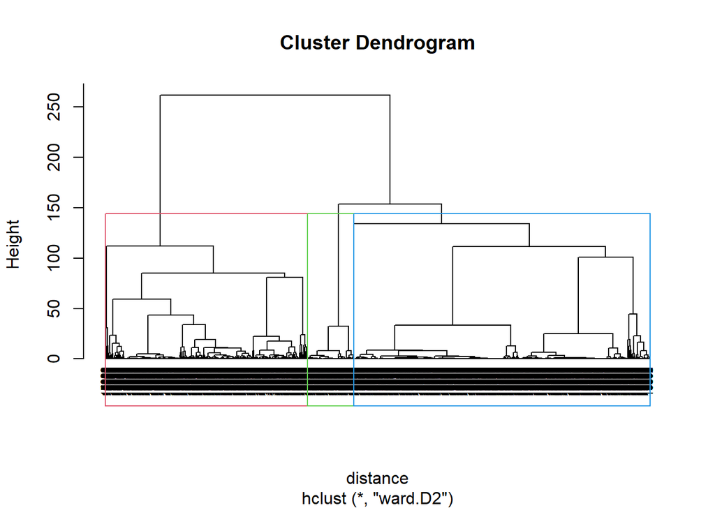

```r
# Plotting the dendrogram

plot(clusterfuel, cex = 0.6, hang = -1)
rect.hclust(clusterfuel,k=3,border=2:5)
```

*Cut-off height = 135.Therefore number of clusters =3*

*Here we are choosing k value =3 (domain knowledge) so as to find the distribution of 3 types of fuel in each of the clusters*

```r
#cutting the dendrogram tree for k=3

grp <- cutree(clusterfuel, k = 3)
```

```r
# Finding number of members in each of the clusters

table(grp)
```

```
## grp
##    1    2    3
## 4891 3338  771
```

*Based on the number of clusters considered, 3 groups have been formed with 4891,3338,771 data points*

```r
#Binding clusters to main data

data7<- cbind(data6, clustering = grp)
```

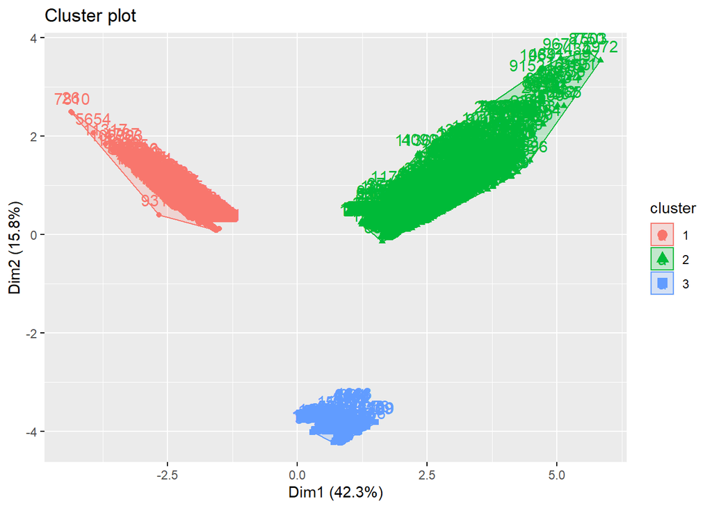

```r
#Cluster visualization

fviz_cluster(list(data = data7, cluster = grp))
```

*The three clusters are named as Coal, Gas and Oil*

*Cluster 1= GAS*

*Cluster 2= COAL*

*Cluster 3= OIL*

```r
#Finding mean of required columns for interpretation

comb_data<-cbind(data7,train[,c(9,11,12,14,15,16)])

fuel<-comb_data %>% mutate(clusters=comb_data$clustering) %>% group_by(clusters)

data9<-fuel[,c(2:11)]%>%group_by(clustering)%>%summarise_all("mean")
```

*Plotting clusters vs other variables*

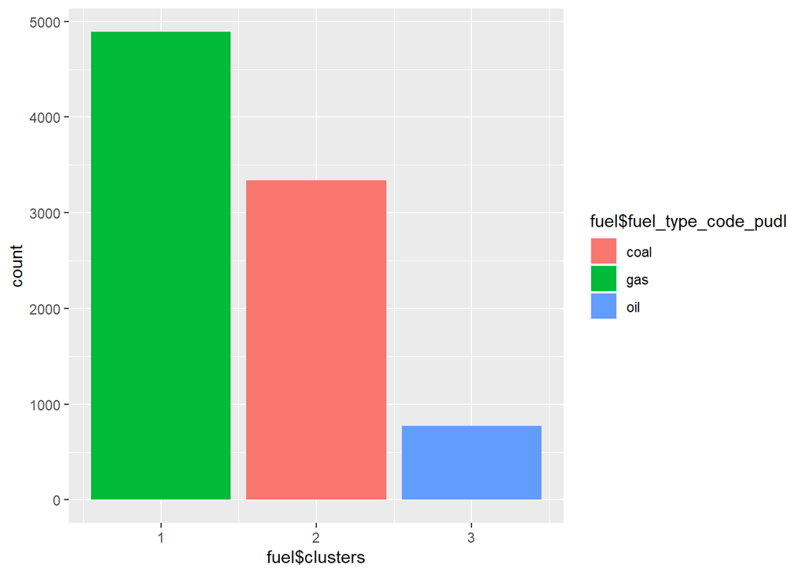

```r
#Cluster vs fuel type

ggplot(fuel, aes(x=fuel$clusters,fill=fuel$fuel_type_code_pudl))+geom_bar()
```

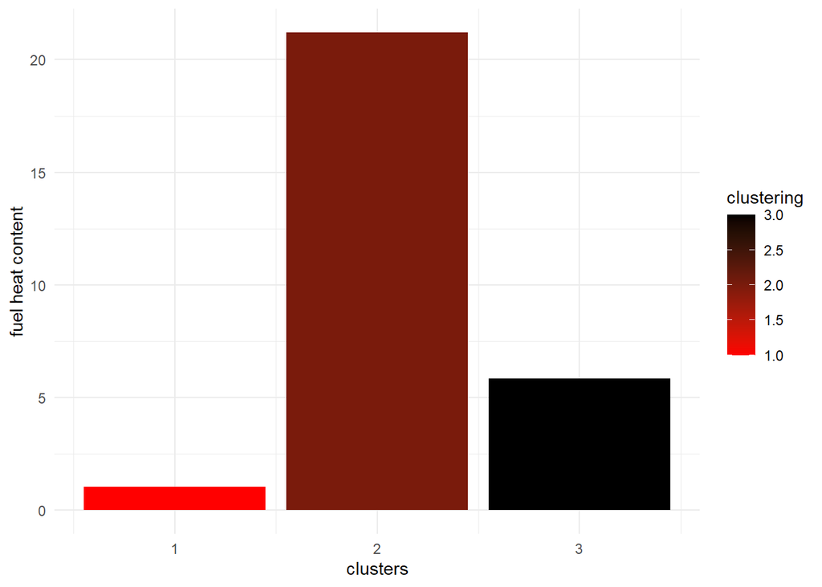

```r
#cluster vs heat content

ggplot(data9, aes(x=clustering, y=fuel_mmbtu_per_unit,fill=clustering)) + geom_bar(stat="identity") +
labs(x="clusters", y="fuel heat content")+scale_fill_gradient(low = "#FF0000", high = "#000000") + theme_minimal()
```

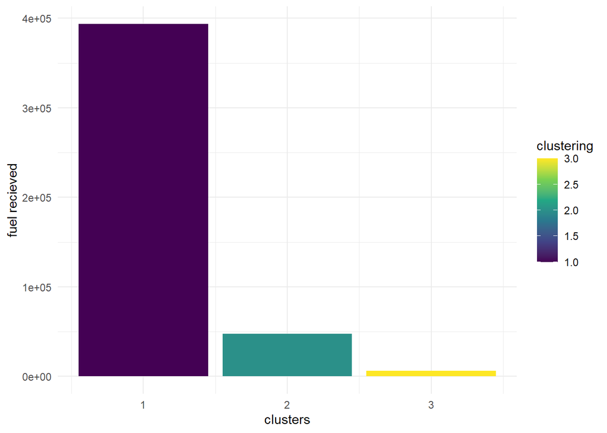

```r
#cluster vs fuel received

ggplot(data9, aes(x=clustering, y=fuel_received_units,fill=clustering)) + geom_bar(stat="identity") +
labs(x="clusters", y="fuel recieved")+scale_fill_viridis_c(option = "viridis", direction = 1) +
theme_minimal()
```

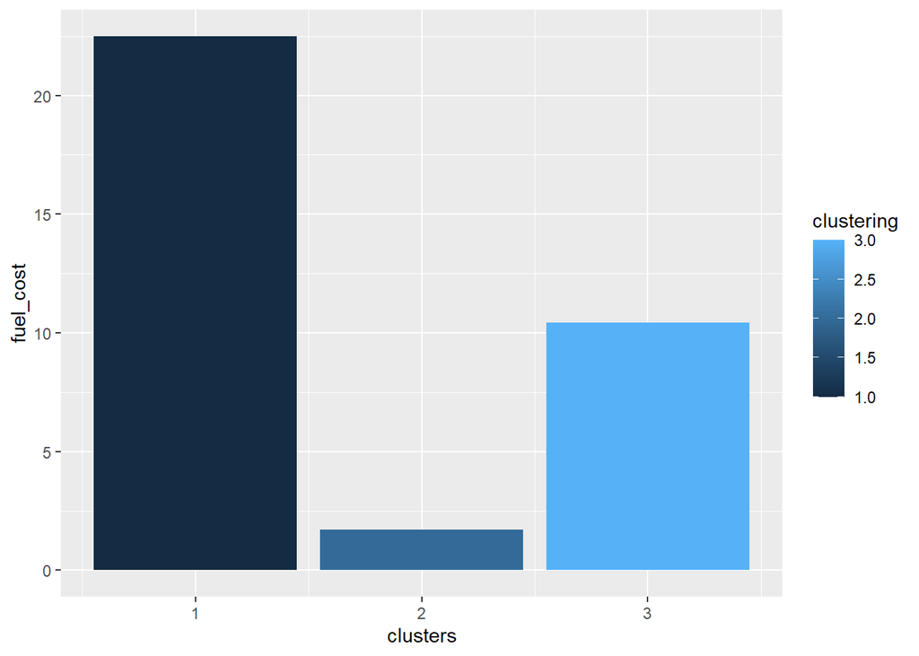

```r
#cluster vs fuel cost

ggplot(data9, aes(x=clustering, y=fuel_cost_per_mmbtu,fill=clustering)) + geom_bar(stat="identity") +
labs(x="clusters", y="fuel_cost")
```

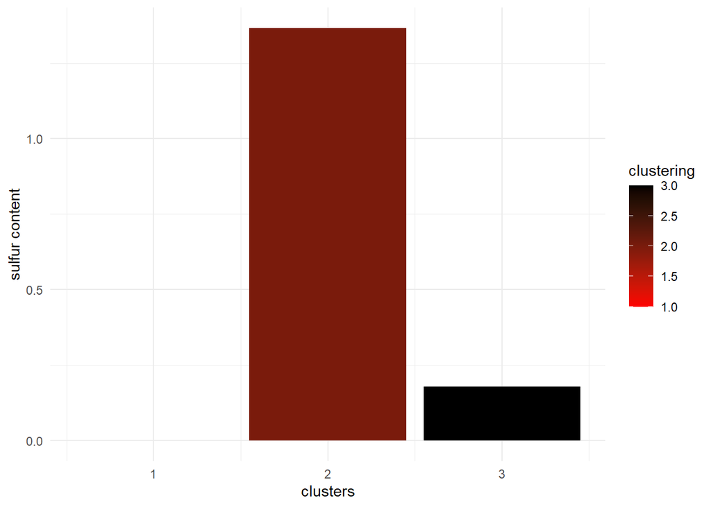

```r
# cluster vs sulfur content

ggplot(data9, aes(x=clustering, y=sulfur_content_pct,fill=clustering)) + geom_bar(stat="identity") +
labs(x="clusters", y="sulfur content")+scale_fill_gradient(low = "#FF0000", high = "#000000") + theme_minimal()
```

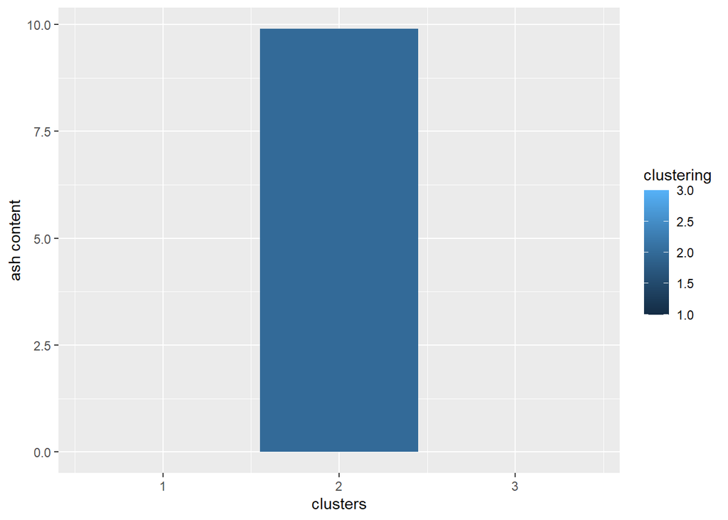

```r
#cluster vs ash content

ggplot(data9, aes(x=clustering, y=ash_content_pct,fill=clustering)) + geom_bar(stat="identity") +
labs(x="clusters", y="ash content")
```

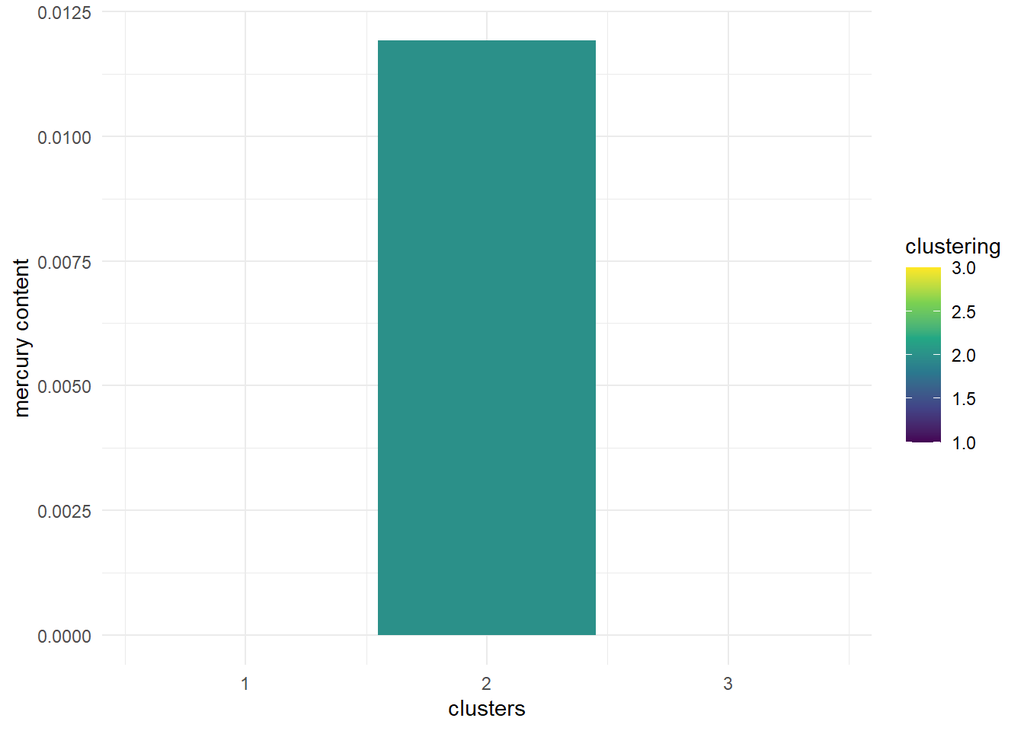

```r
#cluster vs mercury content

ggplot(data9, aes(x=clustering, y=mercury_content_ppm,fill=clustering)) + geom_bar(stat="identity") +
labs(x="clusters", y="mercury content")+scale_fill_viridis_c(option = "viridis", direction = 1) +
theme_minimal()
```

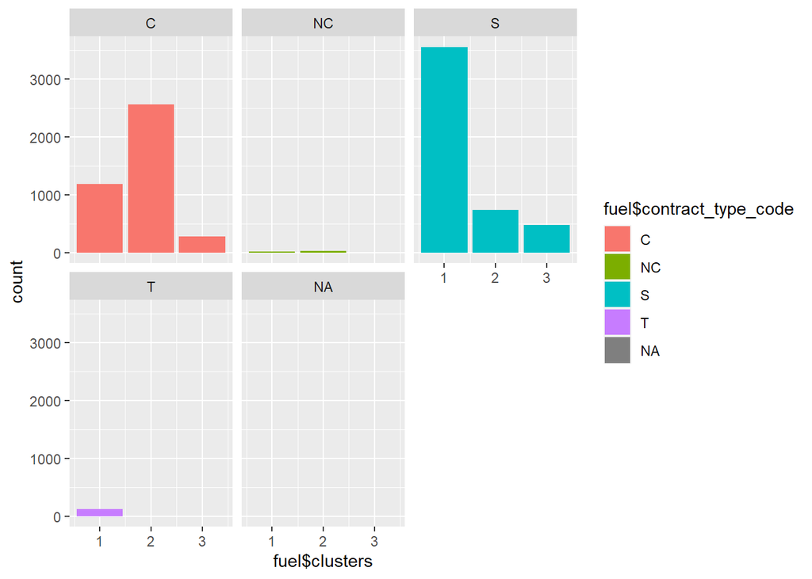

```r
#cluster vs contract type

ggplot(fuel, aes(x=fuel$clusters,fill=fuel$contract_type_code))+geom_bar(position=position_dodge())+facet_wrap(~contract_type_code)
```

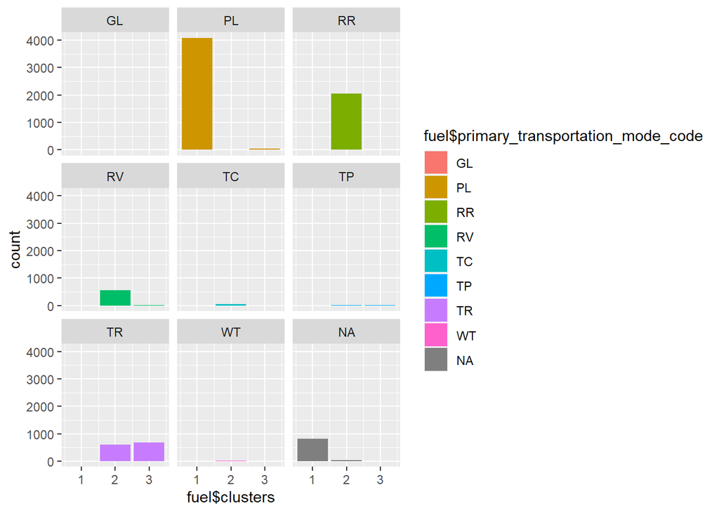

```r
#cluster vs transportation mode

ggplot(fuel, aes(x=fuel$clusters,fill=fuel$primary_transportation_mode_code))+geom_bar(position=position_dodge())+facet_wrap(~primary_transportation_mode_code)
```

*ANALYSIS OF CLUSTERS*

**CLUSTER ONE: GAS**

*Gas is the main fuel type used in this cluster.*

*Gas is free from components like mercury, sulphur and ash.*

*Pipeline is the transportation method used for this type of fuel.*

**CLUSTER TWO:COAL**

*Fuel type used in this cluster is coal.*

*Average units of coal received is 46216 units*

*Average heat content of the fuel is 21.32 which is higher than other two fuels.*

*Coal fuel has an average mercury content of 0.011%,sulfur content of 1.38% and ash content of 9.93%.*

*Coal energy is cheaper when compared with gas and oil and average fuel cost per MMBtu is 1.70 USD.*

**CLUSTER THREE :OIL**

*Oil or Petroleum is the fuel type used*

*Total quantity of fuel received is 6083 units.*

*Fuel heat content is 5.83 units which is greater than gas.*

*This type of fuel is free from mercury and ash content ,but contains a little of 0.19% of sulphur .*

**Extra Credit**

```r
#building the model

model<-lm(data6$fuel_cost_per_mmbtu~.,data=data6)

summary(model)
```

```
##
## Call:
## lm(formula = data6$fuel_cost_per_mmbtu ~ ., data = data6)
##
## Residuals:
##    Min     1Q Median     3Q    Max
##    -48    -18     -6      2  88255
##
## Coefficients: (1 not defined because of singularities)
##                       Estimate Std. Error t value Pr(>|t|)
## (Intercept)          3.173e+00  4.378e+01   0.072    0.942
## plant_id_eia         6.253e-04  4.773e-04   1.310    0.190
## fuel_received_units -1.295e-05  1.511e-05  -0.857    0.391
## fuel_mmbtu_per_unit -1.128e-01  4.969e+00  -0.023    0.982
## sulfur_content_pct   3.818e-01  1.557e+01   0.025    0.980
## ash_content_pct     -4.458e-01  2.270e+00  -0.196    0.844
## mercury_content_ppm -9.208e+00  3.237e+02  -0.028    0.977
## fuel_coal            5.710e-01  8.668e+01   0.007    0.995
## fuel_gas             8.227e+00  4.320e+01   0.190    0.849
## fuel_oil                    NA         NA      NA       NA
##
## Residual standard error: 931.3 on 8991 degrees of freedom
## Multiple R-squared:  0.0003543,  Adjusted R-squared:  -0.0005352
## F-statistic: 0.3983 on 8 and 8991 DF,  p-value: 0.9221
```

```r
#Finding variable importance

varImp(model)
```

```
##                        Overall
## plant_id_eia        1.31003883
## fuel_received_units 0.85727121
## fuel_mmbtu_per_unit 0.02269619
## sulfur_content_pct  0.02451987
## ash_content_pct     0.19640185
## mercury_content_ppm 0.02844559
## fuel_coal           0.00658687
## fuel_gas            0.19045082
```

*Here we can see that our p value is greater than 5 % and r squared value is too low.* *This means variables we considered doesnot account to the variability for fuel cost per mmbtu variable*